# Mixed Model Analysis of Individual Effects

Outline for paper:

Introduction Start with background on Botella paper, etc Point out argument that we can do with our data Potentially other ways to look at Data

Section 1 Go through and replicate their analysis on Experiment 1 (whitehead, et al., 2018) for only simon/stroop/or flanker task (pick their task)

Section 2 Go through and show how this is mathematically the same as using a random effects model to pull estimates from people random effects model is like a ‘type 3’ estimate of values botella approach was more like ‘type 1’ SS only accounting for things in model, not other parameters Show results from mixed effects models in lme (though maybe do in brms for actual confidence intervals)

Section 3 Demonstrate suing their method the variance over the course of the experiment and how that reflects the high degree of error in CIs we see in the mixed models

Discussion Profit Why are things so variable? Need more thoughts.

# Experiment 1

## Create Linear Mixed Model for each task

```r
library(lme4)
model.simon <- lme4::lmer((RT) ~ prevcon*Congruency+(1+prevcon*Congruency|Subject), data = df.simon)
```

```
singular fit
```

```r
model.stroop <- lme4::lmer((RT) ~ prevcon*Congruency+(1+prevcon*Congruency|Subject), data = df.stroop)
```

```
singular fit
```

```r
model.flanker <- lme4::lmer((RT) ~ prevcon*Congruency+(1+prevcon*Congruency|Subject), data = df.flanker)
```

```
singular fit
```

## Get point estimates and ‘prediction intervals’ for each random effect in model

```r
simon.congruency
```

[output not shown]

[output cut: 164 more lines]

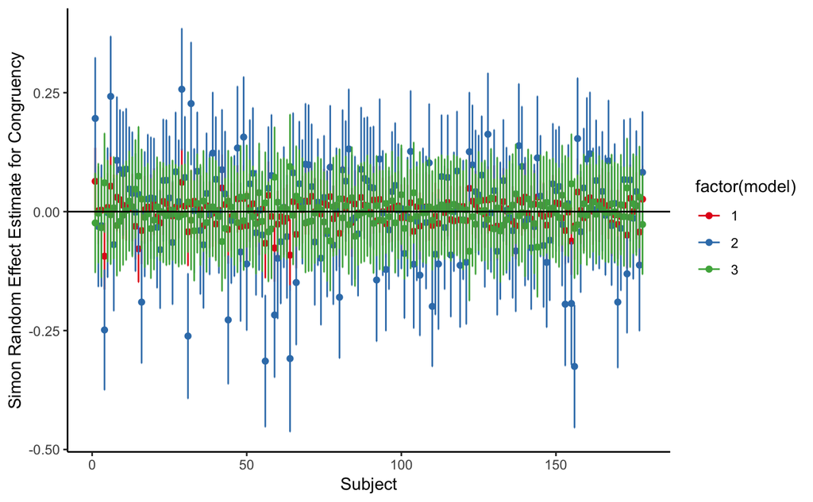

```r
simon.congruency <- #as.data.frame(rbind(Randomeffect.CIs(model.simon, 4))) %>%
  as.data.frame(rbind(Randomeffect.CIs(model.simon, 2),
                                        Randomeffect.CIs(model.simon, 3),
                                        Randomeffect.CIs(model.simon, 4))) %>%
  #arrange(V1) %>%
  #mutate(order = rep(1:178), bestmodel = (ifelse((V3 < 0 | V2 > 0),1,0)))
  mutate(order = rep(1:178,3), model = rep(1:3,each=178))
library(ggplot2)
ggplot(simon.congruency,
       aes(x = order, y = V1,
          color = factor(model), group = factor(model))
          #color = factor(bestmodel))
       ) +
  geom_point() +
  geom_errorbar(aes(ymin=V2, ymax=V3), width=.2) +
  scale_color_brewer(palette = "Set1") +
  xlab("Subject") + ylab("Simon Random Effect Estimate for Congruency") +
  geom_hline(yintercept=0) +
  theme_classic()
```

```r
#plot stuff
ggplot(plot.CI.simon.congruency,
       aes(x = order, y = point, color = bestmodel)) +
  geom_point() +
  geom_errorbar(aes(ymin=lwr, ymax=upr), width=.2) +
  scale_color_brewer(palette = "Set1") +
  xlab("Subject") + ylab("Simon Random Effect Estimate for Congruency") +
  geom_hline(yintercept=0) +
  theme_classic()

ggplot(plot.CI.flanker.congruency,
       aes(x = order, y = point, color = bestmodel)) +
  geom_point() +
  geom_errorbar(aes(ymin=lwr, ymax=upr), width=.2) +
  scale_color_brewer(palette = "Set1") +
  xlab("Subject") + ylab("Flanker Random Effect Estimate for Congruency") +
  geom_hline(yintercept=0) +
  theme_classic()

ggplot(plot.CI.stroop.congruency,
       aes(x = order, y = point, color = bestmodel)) +
  geom_point() +
  geom_errorbar(aes(ymin=lwr, ymax=upr), width=.2) +
  scale_color_brewer(palette = "Set1") +
  xlab("Subject") + ylab("Stroop Random Effect Estimate for Congruency") +
  geom_hline(yintercept=0) +
  theme_classic()

ggplot(plot.CI.simon.prevcon,
       aes(x = order, y = point, color = bestmodel)) +
  geom_point() +
  geom_errorbar(aes(ymin=lwr, ymax=upr), width=.2) +
  scale_color_brewer(palette = "Set1") +
  xlab("Subject") + ylab("Simon Random Effect Estimate for PrevCon") +
  geom_hline(yintercept=0) +
  theme_classic()

ggplot(plot.CI.flanker.prevcon,
       aes(x = order, y = point, color = bestmodel)) +
  geom_point() +
  geom_errorbar(aes(ymin=lwr, ymax=upr), width=.2) +
  scale_color_brewer(palette = "Set1") +
  xlab("Subject") + ylab("Flanker Random Effect Estimate for PrevCon") +
  geom_hline(yintercept=0) +
  theme_classic()

ggplot(plot.CI.stroop.prevcon,
       aes(x = order, y = point, color = bestmodel)) +
  geom_point() +
  geom_errorbar(aes(ymin=lwr, ymax=upr), width=.2) +
  scale_color_brewer(palette = "Set1") +
  xlab("Subject") + ylab("Stroop Random Effect Estimate for PrevCon") +
  geom_hline(yintercept=0) +
  theme_classic()

ggplot(plot.CI.simon.int,
       aes(x = order, y = point, color = bestmodel)) +
  geom_point() +
  geom_errorbar(aes(ymin=lwr, ymax=upr), width=.2) +
  scale_color_brewer(palette = "Set1") +
  xlab("Subject") + ylab("Simon Random Effect Estimate for Interaction") +
  geom_hline(yintercept=0) +
  theme_classic()

ggplot(plot.CI.flanker.int,
       aes(x = order, y = point, color = bestmodel)) +
  geom_point() +
  geom_errorbar(aes(ymin=lwr, ymax=upr), width=.2) +
  scale_color_brewer(palette = "Set1") +
  xlab("Subject") + ylab("Flanker Random Effect Estimate for Interaction") +
  geom_hline(yintercept=0) +
  theme_classic()

ggplot(plot.CI.stroop.int,
       aes(x = order, y = point, color = bestmodel)) +
  geom_point() +
  geom_errorbar(aes(ymin=lwr, ymax=upr), width=.2) +
  scale_color_brewer(palette = "Set1") +
  xlab("Subject") + ylab("Stroop Random Effect Estimate for Interaction") +
  geom_hline(yintercept=0) +
  theme_classic()
```

[output not shown]